# Parametric Tests

[Sushank Pokhrel (Homepage)](https://sushank.com.np)

Loading Required Libraries

```r
library(readxl) # for reading the excel file.
```

```r
library(ggplot2) # for visualizing data
library(dplyr) # cleaning and filtering data
library(tidyr) # data cleaning and manipulating
library(rstatix) # for performing statistical tests.
```

**Importing the Dataset**

```r
dummy_data <- readxl::read_excel(
  "D:/Drive/r_training/Datasets/dummy_data.xlsx",
  sheet = "Sheet1"
)
```

- ’read_excel()’Reads an Excel file from the specified path (“D:/Drive/r_training/Datasets/dummy_data.xlsx”).
- The sheet = “Sheet1” argument specifies the worksheet to load.

Exploring the Data Structure

```r
str(dummy_data)
```

```
## tibble [1,500 × 3] (S3: tbl_df/tbl/data.frame)
##  $ data1: num [1:1500] 84.4 50.1 72 81.1 38.5 ...
##  $ data2: num [1:1500] 62.3 84 81.9 94.1 75.5 ...
##  $ data3: num [1:1500] 33 46.7 26.7 56.4 38.8 ...
```

**For ANOVA or T-test using the package `rstatix` in R to work, data needs to be structured in a “long format,” where a single column holds the values and another column indicates the grouping variable.**

### 1. Restructuring Data for ANOVA

In the given dataset, the columns data1, data2, and data3 represent separate variables. To perform T-test or ANOVA, the data needs to be reshaped into a long format, where:

- One column (variable) indicates the category (e.g., data1, data2, data3).
- Another column (values) contains the corresponding numerical values.

#### Using `pivot_longer()` to Reshape Data

- The `pivot_longer()` function from the tidyr package transforms data from a wide format to a long format.
- The default dataset structure (wide format) isn’t suitable for many statistical tests, including ANOVA, as these tests require a grouping variable. The long format enables:
- Clear identification of groups (e.g., data1, data2, data3) using the variable column.
- Simplified plotting and statistical analysis using functions in R.

```r
library(tidyr)

long_data <- dummy_data |>
  pivot_longer(
    cols = c(data1, data2, data3), # Specify columns to reshape
    names_to = "variable",        # Create a column to hold variable names
    values_to = "values"          # Create a column to hold values
  )
```

- `cols`: The columns you want to transform into a single column.
- `names_to`: The name of the new column that will store the original column names (data1, data2, data3).
- `values_to`: The name of the new column that will hold the values from data1, data2, and data3.

### 2. Handling Missing Data

Check for missing values and remove them to ensure clean data for analysis.

```r
sum(is.na(long_data$values))  # Check for missing values
```

```
## [1] 777
```

```r
long_data <- long_data |> na.omit()  # Remove rows with missing values

str(long_data)
```

```
## tibble [3,723 × 2] (S3: tbl_df/tbl/data.frame)
##  $ variable: chr [1:3723] "data1" "data2" "data3" "data1" ...
##  $ values  : num [1:3723] 84.4 62.3 33 50.1 84 ...
##  - attr(*, "na.action")= 'omit' Named int [1:777] 3070 3073 3076 3079 3082 3085 3088 3091 3094 3097 ...
##   ..- attr(*, "names")= chr [1:777] "3070" "3073" "3076" "3079" ...
```

```r
head(long_data, 10)
```

```
## # A tibble: 10 × 2
##    variable values
##    <chr>     <dbl>
##  1 data1      84.4
##  2 data2      62.3
##  3 data3      33.0
##  4 data1      50.1
##  5 data2      84
##  6 data3      46.7
##  7 data1      72
##  8 data2      81.9
##  9 data3      26.7
## 10 data1      81.1
```

### 3. Visualizing the Data

#### Density Plot

Vieweing the distribution of all three groups

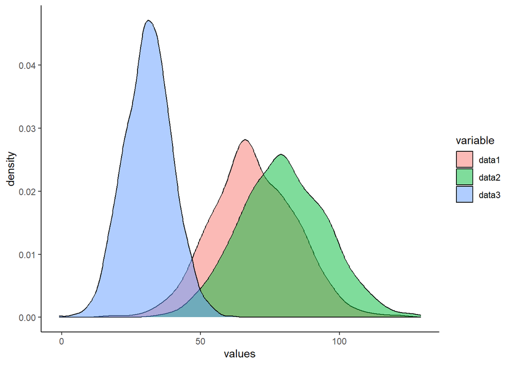

```r
library(ggplot2)

ggplot() +
  geom_density(
    data = long_data,
    aes(x = values, fill = variable),
    alpha = 0.5
  ) +
  theme_classic()
```

- geom_density(): Creates the density plot.
- aes(x = values, fill = variable):
- x = values: Represents the numerical data to be visualized.
- fill = variable: Colors the density curves by the grouping variable.
- alpha = 0.5: Adjusts the transparency of the fill colors for better overlap visualization.

#### Violin and Boxplot

To study the distribution, central tendency, and variability of the data, combine violin plots (to visualize distributions) with boxplots (to show medians and quartiles).

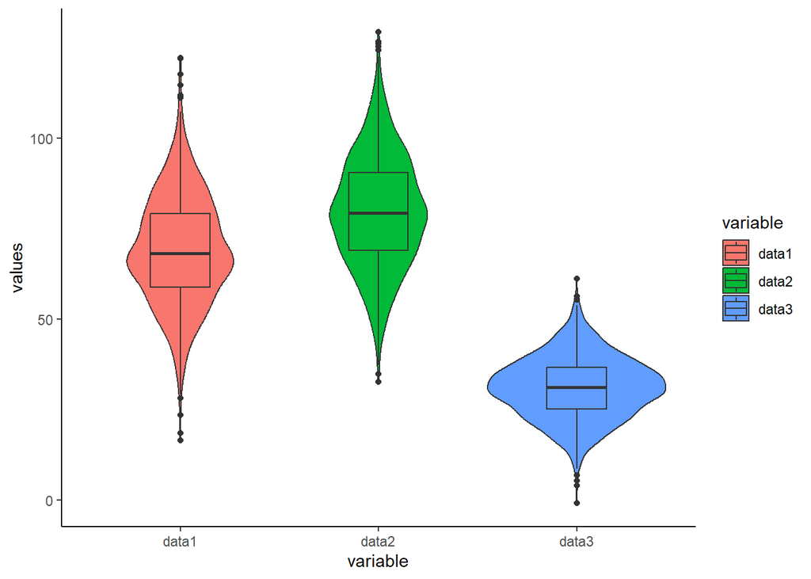

```r
ggplot(
  data = long_data,
  aes(x = variable, y = values, fill = variable)
) +
  geom_violin() +
  geom_boxplot(width = 0.3) + # Add boxplots inside violins
  theme_classic()
```

- `geom_violin()`: Creates the violin plot to show the distribution shape.
- `geom_boxplot()`: Adds boxplots within the violins to display medians, quartiles, and outliers.
- The `width = 0.3` argument narrows the boxplot so it doesn’t obscure the violin plot.

### 3. T-test

The t-test is used to compare the means of two groups to determine if they are significantly different from each other.

It assumes that:

- The data is normally distributed.
- Variances are equal (for a standard independent t-test).
- Since we are analyzing only two groups, we filter the data accordingly.

The original dataset contains three groups (data1, data2, and data3). For a t-test, we filter only two groups: data1 and data2.

```r
# Filter only two groups: data1 and data2
t_test_data <- long_data |>
  dplyr::filter(variable %in% c("data1", "data2"))
```

#### Performing the t-test

```r
library(rstatix)

t_test_result <- t_test(
  data = t_test_data,
  formula = values ~ variable,

)

# Display the results
t_test_result
```

```
## # A tibble: 1 × 8
##   .y.    group1 group2    n1    n2 statistic    df        p
## * <chr>  <chr>  <chr>  <int> <int>     <dbl> <dbl>    <dbl>
## 1 values data1  data2   1023  1500     -17.0 2236. 5.71e-61
```

Interpreting the Output * `p < 0.05`: Reject the null hypothesis. There is a significant difference between the means of the two groups. * `p ≥ 0.05`: Fail to reject the null hypothesis. The difference is not statistically significant.

#### Visualizing the Results

To visualize the difference, we can plot a boxplot with annotations indicating statistical significance.

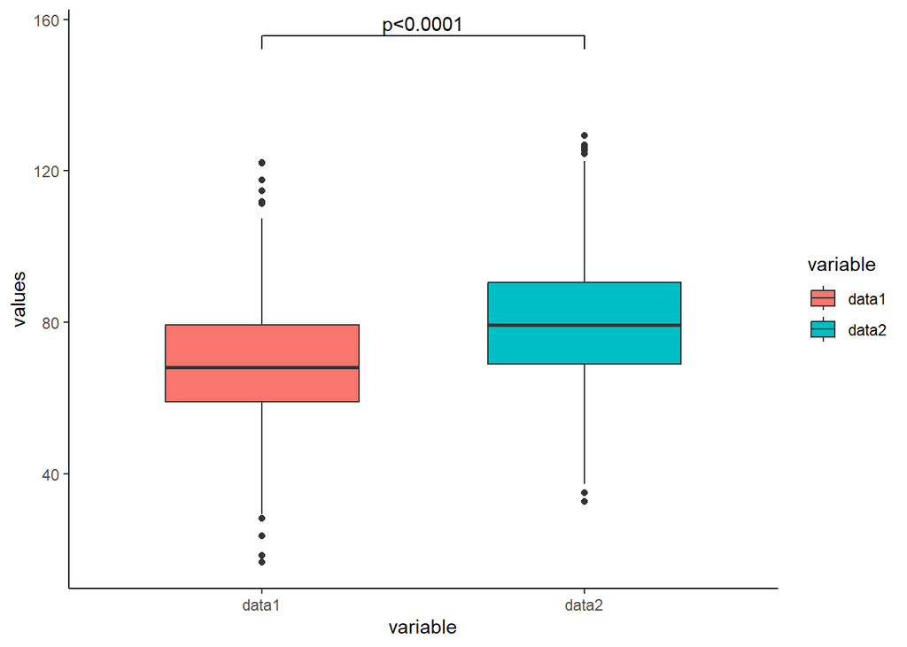

```r
library(ggsignif)

ggplot(
  data = t_test_data,
  aes(x = variable, y = values, fill = variable)
) +
  geom_boxplot(width = 0.6) +
  theme_classic() +
  geom_signif(
    comparisons = list(c("data1", "data2")),
    annotations = "p<0.0001", # Add p-value symbol
    y_position = 150
  )
```

### 4. ANOVA and Post-Hoc Analysis

The Analysis of Variance (ANOVA) test is used to compare the means of multiple groups to determine if they differ significantly. If significant differences are found, a post-hoc test like Tukey’s HSD is used to identify which groups differ.

Assumptions of ANOVA:

- The data should follow a normal distribution (check with normality tests).
- Homogeneity of variance (equal variances across groups).
- Independent observations.

We use the anova_test() function from the rstatix package to perform the ANOVA test. This function simplifies ANOVA and integrates well with tidy data workflows.

Hypotheses for ANOVA test:

- Null Hypothesis (H₀): The means of all groups are equal.
- Alternative Hypothesis (H₁): At least one group mean is different.

#### ANOVA Test

```r
# Perform the ANOVA test
anova_values <- anova_test(
  data = long_data,
  formula = values ~ variable
)

anova_values
```

```
## ANOVA Table (type II tests)
##
##     Effect DFn  DFd        F p p<.05   ges
## 1 variable   2 3720 4488.292 0     * 0.707
```

Function Overview:

The forumla Specifies the relationship where values is the dependent variable and variable is the grouping factor. The result

- Includes F-statistic, p-value, and degrees of freedom (Df).
- p-value less than 0.05 indicates significant differences among group means.

Here, there’s a significant difference between the groups as p value is shown as zero. Also, the asterisk sign is also helpful.

#### Performing Post-Hoc Test: Tukey’s HSD

When ANOVA detects significant differences, Tukey’s Honest Significant Difference (HSD) test determines which group pairs have different means.

```r
tukey_values <- tukey_hsd(
  x = long_data,
  formula = values ~ variable
)

tukey_values
```

```
## # A tibble: 3 × 9
##   term     group1 group2 null.value estimate conf.low conf.high        p.adj
## * <chr>    <chr>  <chr>       <dbl>    <dbl>    <dbl>     <dbl>        <dbl>
## 1 variable data1  data2           0     10.6     9.29      11.9 0.0000000105
## 2 variable data1  data3           0    -38.0   -39.4      -36.6 0.0000000105
## 3 variable data2  data3           0    -48.6   -49.8      -47.3 0.0000000105
## # ℹ 1 more variable: p.adj.signif <chr>
```

The result:

- Group Comparisons: Lists pairwise comparisons (e.g., data1 vs. data2).
- Adjusted p-values (`p.adj`): Used to interpret the significance of each pair.
- A smaller p-value (`e.g., < 0.05`) indicates significant differences between groups.

#### Visualizing ANOVA Results with Significance

To enhance the visualization of group differences, we can:

- Plot the distributions with violin and boxplots.
- Add significance annotations using the ggsignif package.
- Adding Significance Information

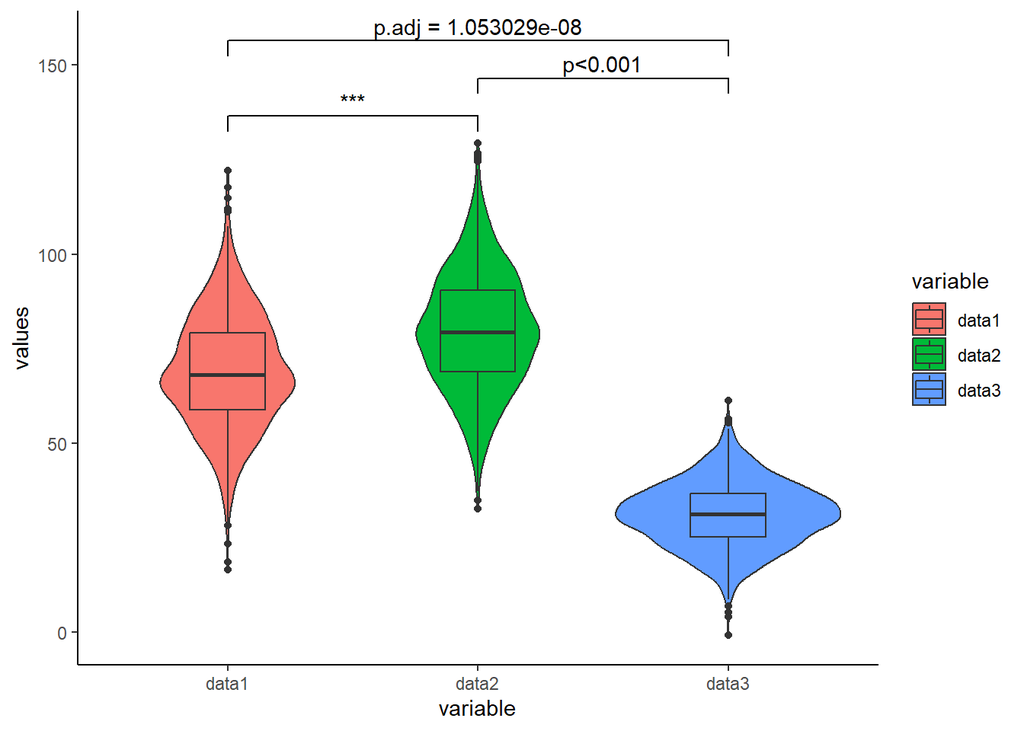

```r
# Install and load ggsignif
library(ggsignif)

# Visualization with significance annotations
ggplot(
  data = long_data,
  aes(x = variable, y = values, fill = variable)
) +
  geom_violin() +
  geom_boxplot(width = 0.3) + # Adds boxplot
  theme_classic() +
  geom_signif(
    comparisons = list(
      c("data1", "data2"),
      c("data2", "data3"),
      c("data1", "data3")
    ),
    y_position = c(130, 140, 150), # Adjust height of annotations
    annotations = c("***", "p<0.001", "p.adj = 1.053029e-08")
  )
```